# 04 - Prior Sensitivity and Structural Robustness

Airline Customer Satisfaction – Bayesian Learning & Monte Carlo Simulations, 2026

This notebook stress-tests the conclusions of Section 02 (vague-prior logit) and Section 03 (horseshoe) against the choices we made along the way. We ask three questions: does the vague model’s posterior depend on the prior *variance* we picked? Does the horseshoe’s signal/noise verdict depend on the *global scale* of its half-Cauchy prior? And does the counter-intuitive `Departure/Arrival time convenient` coefficient from Section 03 survive dropping the ambiguous structural-zero rows?

All the following checks require heacy JAGS fits, so we decided to split those in separate script files (`04a_prior_sweep.R`, `04b_horseshoe_prior_sweep.R`, `04c_structural_zero_refit.R`) to avoid excessive long cells in this notebook. Scripts are meant to be executed ocne and then re-use their stored output.

```r
train <- read.csv("../data/airline_train_n1200.csv", stringsAsFactors = FALSE)
train$y <- as.integer(train$satisfaction == "satisfied")
std <- function(x) as.numeric(scale(x))
```

# 1 1. Logit model prior sensitivity

We refit Section 02’s model (vague priors, dummy `Class` encoding) four times, varying only the prior variance on every $\beta_j$: $\sigma^2_\beta \in \{1, 10, 100, 10000\}$. The fits are produced by `04a_prior_sweep.R`.

```r
# Coefficient order returned by the sweep: beta[1..8], beta0, beta_arr.
term_labels_vague <- c("beta0" = "Intercept", "beta[1]" = "Age", "beta[2]" = "Seat comfort",
                       "beta[3]" = "Flight Distance", "beta[4]" = "Class: Eco Plus",
                       "beta[5]" = "Class: Business", "beta[6]" = "log(1+Departure Delay)",
                       "beta[7]" = "Personal Travel", "beta[8]" = "disloyal Customer",
                       "beta_arr" = "Mid-flight delay (signed-log)")
```

```r
sweep_results <- readRDS("../data/04a_prior_sweep.rds")
```

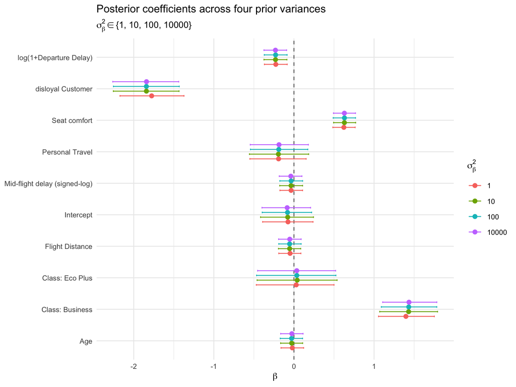

```r
sweep_df <- bind_rows(lapply(names(sweep_results), function(v) {
  df <- sweep_results[[v]]
  df$term <- rownames(df)
  df$variance <- v
  df
}))
sweep_df$term_label <- term_labels_vague[sweep_df$term]
sweep_df$variance <- factor(sweep_df$variance,
                            levels = c("1", "10", "100", "10000"))

ggplot(sweep_df, aes(x = mean, y = term_label, color = variance)) +
  geom_vline(xintercept = 0, linetype = "dashed", color = "grey40") +
  geom_errorbarh(aes(xmin = lo, xmax = hi), height = 0.2,
                 position = position_dodge(width = 0.6)) +
  geom_point(position = position_dodge(width = 0.6), size = 2) +
  labs(title = "Posterior coefficients across four prior variances",
       subtitle = expression(sigma[beta]^2 %in% "{1, 10, 100, 10000}"),
       x = expression(beta), y = NULL, color = expression(sigma[beta]^2)) +
  theme_minimal(base_size = 10)
```

```r
range_tbl <- sweep_df %>%
  group_by(term_label) %>%
  summarise(mean_range = max(mean) - min(mean), .groups = "drop") %>%
  arrange(desc(mean_range))
knitr::kable(range_tbl, digits = 4,
             caption = "Range of posterior means across the four prior variances")
```

Range of posterior means across the four prior variances

| term_label | mean_range |
| --- | --- |
| disloyal Customer | 0.0656 |
| Class: Business | 0.0383 |
| Class: Eco Plus | 0.0118 |
| Intercept | 0.0102 |
| Age | 0.0094 |
| Personal Travel | 0.0075 |
| Seat comfort | 0.0075 |
| Flight Distance | 0.0058 |
| log(1+Departure Delay) | 0.0045 |
| Mid-flight delay (signed-log) | 0.0036 |

The largest movement across four orders of magnitude of prior variance is only 0.066 on the log-odds scale, for a coefficient whose posterior mean is itself on the order of 1-2. At $n=$ 1213. So th likelihood dominates the tested priors.

# 2 Horseshoe prior sensitivity: does the global scale matter?

The horseshoe’s shrinkage behaviour is governed by the scale $s$ of the half-Cauchy prior put on the **global** scale $\tau$:
$$\tau \sim \mathcal{C}^+(0, s)$$
Small $s$ pulls every coefficient hard towards zero (more aggressive sparsity), large $s$ relaxes the global shrinkage. This is the parameter whose choice could plausibly change *which* covariates the model keeps, so it is the one worth testing.

`04b_horseshoe_prior_sweep.R` refits the exact Section 03 model three times, varying only this global scale, $s \in \{0.1, 1, 10\}$ ($s = 1$ is the Section 03 default), while the local scales $\lambda_j$ keep the standard $\mathcal{C}^+(0,1)$. For each fit it stores the posterior mean and $95\%$ credible interval of every coefficient, and the per-predictor shrinkage weight $\kappa_j = 1/(1+\lambda_j^2)$ (near $0$ = signal, near $1$ = shrunk, exactly as in Section 03).

```r
hs_sweep <- readRDS("../data/04b_horseshoe_sweep.rds")
hs_scales <- names(hs_sweep)

hs_df <- bind_rows(lapply(hs_scales, function(s) {
  d <- hs_sweep[[s]]
  d$scale <- s
  d
}))
hs_df$scale <- factor(hs_df$scale, levels = hs_scales)
```

## 2.1 Coefficients across global scales

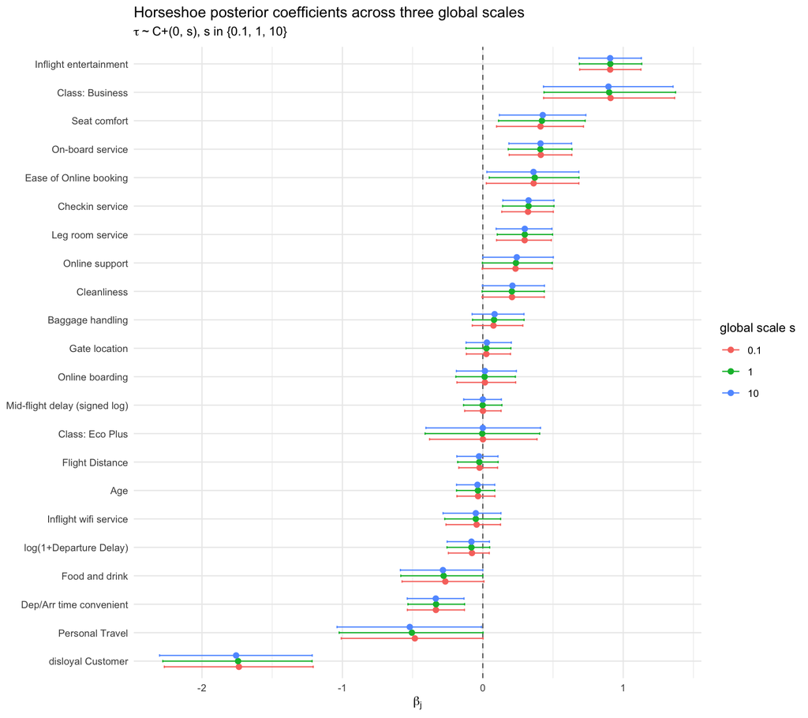

```r
ggplot(hs_df, aes(x = beta_mean, y = reorder(term, beta_mean), color = scale)) +
  geom_vline(xintercept = 0, linetype = "dashed", color = "grey40") +
  geom_errorbarh(aes(xmin = beta_lo, xmax = beta_hi), height = 0.25,
                 position = position_dodge(width = 0.6)) +
  geom_point(position = position_dodge(width = 0.6), size = 1.8) +
  labs(title = "Horseshoe posterior coefficients across three global scales",
       subtitle = expression(tau %~% "C+(0, s), s in {0.1, 1, 10}"),
       x = expression(beta[j]), y = NULL, color = "global scale s") +
  theme_minimal(base_size = 10)
```

```r
hs_range <- hs_df %>%
  group_by(term) %>%
  summarise(beta_range = max(beta_mean) - min(beta_mean), .groups = "drop") %>%
  arrange(desc(beta_range))
knitr::kable(head(hs_range, 8), digits = 3,
             caption = "Largest movement of the posterior mean across the three global scales")
```

Largest movement of the posterior mean across the three global scales

| term | beta_range |
| --- | --- |
| Personal Travel | 0.036 |
| disloyal Customer | 0.020 |
| Food and drink | 0.017 |
| Seat comfort | 0.016 |
| Class: Business | 0.015 |
| Ease of Online booking | 0.009 |
| Online support | 0.009 |
| Baggage handling | 0.008 |

## 2.2 Shrinkage weights and signal/noise stability

```r
kappa_wide <- hs_df %>%
  select(term, scale, kappa) %>%
  pivot_wider(names_from = scale, values_from = kappa)
knitr::kable(kappa_wide, digits = 3,
             caption = "Posterior shrinkage weight kappa_j at each global scale")
```

Posterior shrinkage weight kappa_j at each global scale

| term | 0.1 | 1 | 10 |
| --- | --- | --- | --- |
| Seat comfort | 0.322 | 0.366 | 0.382 |
| Dep/Arr time convenient | 0.363 | 0.419 | 0.431 |
| Food and drink | 0.446 | 0.483 | 0.491 |
| Gate location | 0.736 | 0.755 | 0.763 |
| Inflight wifi service | 0.704 | 0.709 | 0.716 |
| Inflight entertainment | 0.128 | 0.171 | 0.181 |
| Online support | 0.467 | 0.515 | 0.525 |
| Ease of Online booking | 0.364 | 0.403 | 0.434 |
| On-board service | 0.302 | 0.367 | 0.375 |
| Leg room service | 0.394 | 0.444 | 0.462 |
| Baggage handling | 0.688 | 0.700 | 0.699 |
| Checkin service | 0.363 | 0.428 | 0.437 |
| Cleanliness | 0.498 | 0.541 | 0.555 |
| Online boarding | 0.718 | 0.734 | 0.742 |
| Age | 0.751 | 0.761 | 0.753 |
| Flight Distance | 0.754 | 0.763 | 0.768 |
| Class: Eco Plus | 0.647 | 0.658 | 0.680 |
| Class: Business | 0.134 | 0.184 | 0.192 |
| log(1+Departure Delay) | 0.686 | 0.702 | 0.715 |
| Personal Travel | 0.314 | 0.349 | 0.354 |
| disloyal Customer | 0.050 | 0.070 | 0.076 |
| Mid-flight delay (signed log) | 0.762 | 0.762 | 0.791 |

```r
signal_wide <- hs_df %>%
  mutate(signal = kappa < 0.5) %>%
  select(term, scale, signal) %>%
  pivot_wider(names_from = scale, values_from = signal)

signal_cols <- setdiff(names(signal_wide), "term")
signal_wide$stable <- apply(signal_wide[, signal_cols], 1,
                            function(r) length(unique(r)) == 1)
n_flips <- sum(!signal_wide$stable)

# predictors classified as signal (kappa < 0.5) under the default scale s = 1
default_signal <- signal_wide$term[signal_wide[["1"]]]

knitr::kable(signal_wide, caption = "Signal (kappa < 0.5) at each scale; `stable` = same verdict across all three")
```

Signal (kappa < 0.5) at each scale; `stable` = same verdict across all three

| term | 0.1 | 1 | 10 | stable |
| --- | --- | --- | --- | --- |
| Seat comfort | TRUE | TRUE | TRUE | TRUE |
| Dep/Arr time convenient | TRUE | TRUE | TRUE | TRUE |
| Food and drink | TRUE | TRUE | TRUE | TRUE |
| Gate location | FALSE | FALSE | FALSE | TRUE |
| Inflight wifi service | FALSE | FALSE | FALSE | TRUE |
| Inflight entertainment | TRUE | TRUE | TRUE | TRUE |
| Online support | TRUE | FALSE | FALSE | FALSE |
| Ease of Online booking | TRUE | TRUE | TRUE | TRUE |
| On-board service | TRUE | TRUE | TRUE | TRUE |
| Leg room service | TRUE | TRUE | TRUE | TRUE |
| Baggage handling | FALSE | FALSE | FALSE | TRUE |
| Checkin service | TRUE | TRUE | TRUE | TRUE |
| Cleanliness | TRUE | FALSE | FALSE | FALSE |
| Online boarding | FALSE | FALSE | FALSE | TRUE |
| Age | FALSE | FALSE | FALSE | TRUE |
| Flight Distance | FALSE | FALSE | FALSE | TRUE |
| Class: Eco Plus | FALSE | FALSE | FALSE | TRUE |
| Class: Business | TRUE | TRUE | TRUE | TRUE |
| log(1+Departure Delay) | FALSE | FALSE | FALSE | TRUE |
| Personal Travel | TRUE | TRUE | TRUE | TRUE |
| disloyal Customer | TRUE | TRUE | TRUE | TRUE |
| Mid-flight delay (signed log) | FALSE | FALSE | FALSE | TRUE |

# 3 Structural-zero robustness check

Section 03 speculated that `Departure/Arrival time convenient`’s counter-intuitive *negative* coefficient might be an artefact of the structural zeros flagged in Section 00 (zeros that plausibly mean “not applicable” rather than genuine dissatisfaction). We test that directly by refitting the full horseshoe model with those rows excluded (`04c_structural_zero_refit.R`).

```r
# Section 03 horseshoe summary (full data). The saved object holds the pieces,
# not an assembled table, so rebuild one with the same columns as the refit's
# result_tbl, otherwise the two cannot be bound together below.
s3   <- readRDS("../data/03_horseshoe_summary.rds")
s3$kappa_tbl <- data.frame(
  term      = s3$term_labels[s3$beta_cols],
  kappa     = as.numeric(s3$post_kappa[s3$beta_cols]),
  beta_mean = as.numeric(s3$post_beta[s3$beta_cols]),
  beta_lo   = as.numeric(s3$beta_ci[1, s3$beta_cols]),
  beta_hi   = as.numeric(s3$beta_ci[2, s3$beta_cols]),
  row.names = NULL)
zref <- readRDS("../data/04c_structural_zero_refit.rds")
cat("Rows excluded:", zref$n_excluded, "of", zref$n_excluded + zref$n_remaining, "\n")
```

```
## Rows excluded: 110 of 1213
```

```r
cat("Rows remaining:", zref$n_remaining, "\n")
```

```
## Rows remaining: 1103
```

```r
knitr::kable(zref$result_tbl, row.names = FALSE, digits = 3,
             caption = "Horseshoe refit excluding structural-zero rows")
```

Horseshoe refit excluding structural-zero rows

| term | kappa | beta_mean | beta_lo | beta_hi |
| --- | --- | --- | --- | --- |
| Seat comfort | 0.215 | 0.869 | 0.550 | 1.192 |
| Dep/Arr time convenient | 0.361 | -0.506 | -0.780 | -0.240 |
| Food and drink | 0.732 | 0.025 | -0.215 | 0.299 |
| Gate location | 0.620 | -0.171 | -0.448 | 0.048 |
| Inflight wifi service | 0.681 | -0.108 | -0.399 | 0.099 |
| Inflight entertainment | 0.164 | 1.099 | 0.844 | 1.376 |
| Online support | 0.553 | 0.247 | -0.019 | 0.561 |
| Ease of Online booking | 0.369 | 0.498 | 0.081 | 0.872 |
| On-board service | 0.343 | 0.526 | 0.240 | 0.809 |
| Leg room service | 0.492 | 0.294 | 0.050 | 0.524 |
| Baggage handling | 0.666 | 0.132 | -0.059 | 0.396 |
| Checkin service | 0.429 | 0.376 | 0.156 | 0.592 |
| Cleanliness | 0.610 | 0.159 | -0.059 | 0.428 |
| Online boarding | 0.732 | 0.030 | -0.194 | 0.296 |
| Age | 0.747 | -0.032 | -0.209 | 0.116 |
| Flight Distance | 0.772 | -0.016 | -0.191 | 0.142 |
| Class: Eco Plus | 0.674 | 0.010 | -0.466 | 0.492 |
| Class: Business | 0.219 | 0.936 | 0.378 | 1.518 |
| log(1+Departure Delay) | 0.719 | -0.087 | -0.291 | 0.064 |
| Personal Travel | 0.308 | -0.678 | -1.256 | -0.037 |
| disloyal Customer | 0.061 | -2.298 | -2.998 | -1.621 |
| Mid-flight delay (signed log) | 0.780 | -0.014 | -0.189 | 0.153 |

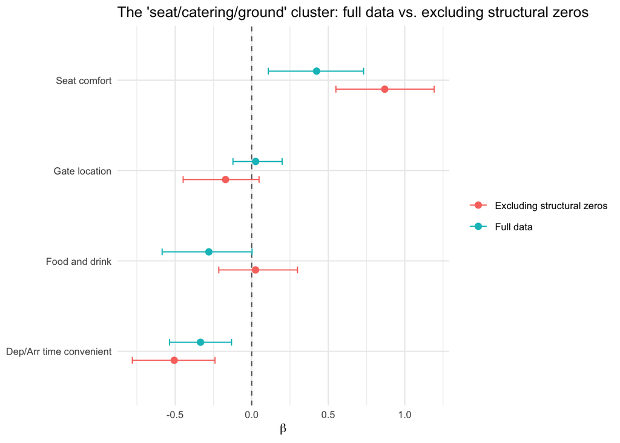

```r
full_tbl <- s3$kappa_tbl %>% mutate(fit = "Full data")
zero_tbl <- zref$result_tbl %>% mutate(fit = "Excluding structural zeros")

compare_df <- bind_rows(full_tbl, zero_tbl) %>%
  filter(term %in% c("Dep/Arr time convenient", "Seat comfort", "Food and drink", "Gate location"))

ggplot(compare_df, aes(x = beta_mean, y = term, color = fit)) +
  geom_vline(xintercept = 0, linetype = "dashed", color = "grey40") +
  geom_errorbarh(aes(xmin = beta_lo, xmax = beta_hi), height = 0.15,
                 position = position_dodge(width = 0.4)) +
  geom_point(position = position_dodge(width = 0.4), size = 2.2) +
  labs(title = "The 'seat/catering/ground' cluster: full data vs. excluding structural zeros",
       x = expression(beta), y = NULL, color = NULL) +
  theme_minimal(base_size = 10)
```

```r
## Model comparison: WAIC and PSIS-LOO

s2 <- readRDS("../data/02_logit_mcmc.rds")
s3 <- readRDS("../data/03_horseshoe_final.rds")

print(s2$loo)
```

```
##
## Computed from 5142 by 1213 log-likelihood matrix.
##
##          Estimate   SE
## elpd_loo   -686.7 16.7
## p_loo        10.4  0.4
## looic      1373.4 33.4
## ------
## MCSE of elpd_loo is 0.0.
## MCSE and ESS estimates assume independent draws (r_eff=1).
##
## All Pareto k estimates are good (k < 0.7).
## See help('pareto-k-diagnostic') for details.
```

```r
print(s3$loo)
```

```
##
## Computed from 30000 by 1213 log-likelihood matrix.
##
##          Estimate   SE
## elpd_loo   -491.9 21.2
## p_loo        21.8  1.3
## looic       983.8 42.4
## ------
## MCSE of elpd_loo is 0.0.
## MCSE and ESS estimates assume independent draws (r_eff=1).
##
## All Pareto k estimates are good (k < 0.7).
## See help('pareto-k-diagnostic') for details.
```

```r
loo_cmp <- loo_compare(list(logit = s2$loo, horseshoe = s3$loo))
print(loo_cmp)
```

```
##      model elpd_diff se_diff p_worse diag_diff diag_elpd
##  horseshoe       0.0     0.0      NA
##      logit    -194.8    17.5    1.00
```

```r
loo_tbl <- data.frame(
  Model = c("Vague-prior logit", "Horseshoe"),
  elpd_loo = c(s2$loo$estimates["elpd_loo","Estimate"], s3$loo$estimates["elpd_loo","Estimate"]),
  SE       = c(s2$loo$estimates["elpd_loo","SE"],       s3$loo$estimates["elpd_loo","SE"]),
  p_loo    = c(s2$loo$estimates["p_loo","Estimate"],    s3$loo$estimates["p_loo","Estimate"]),
  looic    = c(s2$loo$estimates["looic","Estimate"],    s3$loo$estimates["looic","Estimate"])
)
knitr::kable(round(loo_tbl[,-1], 1), row.names = FALSE)
```

| elpd_loo | SE | p_loo | looic |
| --- | --- | --- | --- |
| -686.7 | 16.7 | 10.4 | 1373.4 |
| -491.9 | 21.2 | 21.8 | 983.8 |